# Scales and Facets

```r
library(ggalign)
```

```r
set.seed(123)
small_mat <- matrix(rnorm(81), nrow = 9)
rownames(small_mat) <- paste0("row", seq_len(nrow(small_mat)))
colnames(small_mat) <- paste0("column", seq_len(ncol(small_mat)))
```

## Scales

Scales are handled as the usual in ggplot2, but for position scales, `limits` cannot be setted, and the internal will always reset it as the default. This is required to align the layout and annotation.

```r
ggheatmap(small_mat) + scale_x_continuous(limits = c(0, 0))
```

[output not shown]

`breaks` and `labels` in the position scales are handled in a similar manner of discrete scale, thought you can provide as a continuous scale.

### breaks

`breaks` should be one of:

```
- `NULL` for no breaks

- `waiver()` for the default breaks (the full data index or `NULL` if no
data names and `labels` is `waiver()`)

- A character vector of breaks (rownames / colunames of the matrix).

- A numeric vector of data index.

- A function that takes the data limits or the data index as input and
returns breaks as output. Also accepts rlang lambda function notation.
```

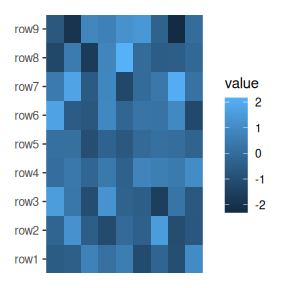

```r
ggheatmap(small_mat) + scale_x_continuous(breaks = NULL)
```

```r
ggheatmap(small_mat) + scale_x_continuous()
```

[output not shown]

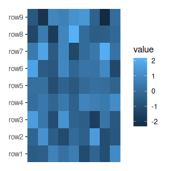

```r
no_names <- small_mat
colnames(no_names) <- NULL
ggheatmap(no_names) + scale_x_continuous()
```

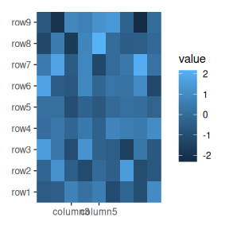

```r
ggheatmap(small_mat) + scale_x_continuous(breaks = c("column3", "column5"))
```

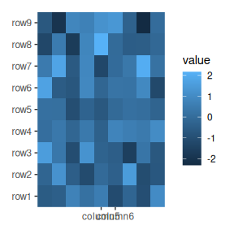

```r
ggheatmap(small_mat) + scale_x_continuous(breaks = 5:6)
```

### labels

`labels` should be one of:

```
- `NULL` for no labels

- `waiver()` for the default labels (data names)

- A character vector giving labels (must be same length as breaks)

- An expression vector (must be the same length as breaks). See `?plotmath`
for details.

- A function that takes the data names (or breaks if data has no names) as
input and returns labels as output. This can be also a rlang lambda
function.
```

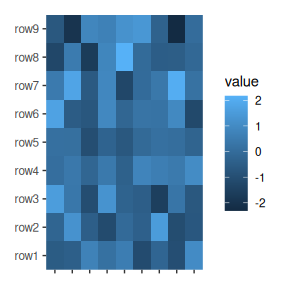

```r
ggheatmap(small_mat) + scale_x_continuous(labels = NULL)
```

```r
ggheatmap(small_mat) + scale_x_continuous()
```

[output not shown]

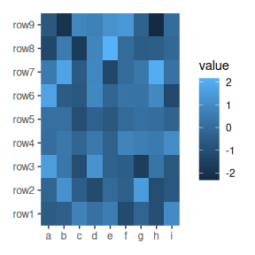

```r
ggheatmap(small_mat) +
  scale_x_continuous(labels = letters[seq_len(ncol(small_mat))])
```

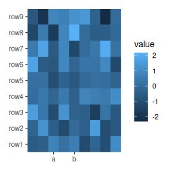

```r
ggheatmap(small_mat) +
  scale_x_continuous(breaks = c(3, 5), labels = c("a", "b"))
```

### data ordering

Both `breaks` and `labels` should be provided in the original scale of the raw matrix, the internal will reorder them accordingly if you reorder the heatmap rows/columns.

`align_reorder` will reorder the heatmap rows/columns based on the weights returned from `fun` argument. Here we reorder the heatmap columns by the means.

We provide the labels in the original order here, the layout will reorder them.

```r
index <- order(colMeans(small_mat))
xlabels <- letters[seq_len(ncol(small_mat))]
print(xlabels[index])
```

```
#> [1] "c" "h" "i" "g" "f" "e" "a" "b" "d"
```

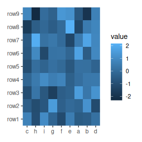

```r
ggheatmap(small_mat) +
  scale_x_continuous(labels = xlabels) +
  hmanno("t") +
  align_reorder()
```

### discrete or continuous

`breaks` and `labels` argument will work the same in both discrete scale and continuous scale. But note it’s hard to match all discrete scale limits, for sometimes, you should manually specify the `expand` argument.

In the following example, we must add `expand` argument to match the heatmap and the hierarchical clustering tree.

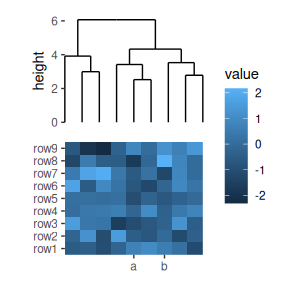

```r
ggheatmap(small_mat) +
  scale_x_discrete(breaks = c(3, 5), labels = c("a", "b")) +
  hmanno("t") +
  align_dendro() +
  scale_x_discrete()
```

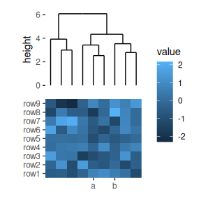

```r
ggheatmap(small_mat) +
  scale_x_discrete(breaks = c(3, 5), labels = c("a", "b")) +
  hmanno("t") +
  align_dendro() +
  scale_x_discrete(expand = expansion(add = 0.5))
```

Indeed, you can use the default scale for the dendrogram directly. The layout always sets the appropriate limits for the continuous scale.

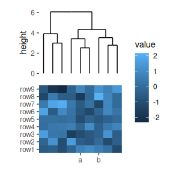

```r
ggheatmap(small_mat) +
  scale_x_discrete(breaks = c(3, 5), labels = c("a", "b")) +
  hmanno("t") +
  align_dendro()
```

One useful feature of the discrete scale is handling ambiguous orientation in geoms. Some geoms, like `ggplot2::geom_bar()` and `ggplot2::geom_boxplot()`, use the discrete axis as the main orientation, but by default, we use the continuous scale. For horizontal layouts (including left and right heatmap annotations), you must manually provide the `orientation` argument for these geoms or set the discrete scale.

In the following example, `geom_bar` won’t work since the ambiguous orientation.

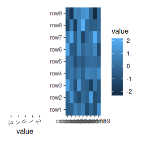

```r
ggheatmap(small_mat) +
  hmanno("l") +
  ggalign() +
  geom_bar(aes(x = value), stat = "identity") +
  theme(axis.text.x = element_text(angle = -60, hjust = 0))
```

Try to provide the `orientation` argument or set the scale into discrete.

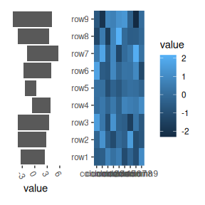

```r
ggheatmap(small_mat) +
  hmanno("l") +
  ggalign() +
  geom_bar(aes(x = value), stat = "identity", orientation = "y") +
  theme(axis.text.x = element_text(angle = -60, hjust = 0))
```

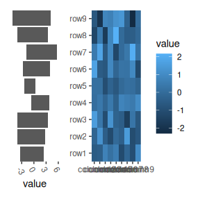

```r
ggheatmap(small_mat) +
  hmanno("l") +
  ggalign() +
  geom_bar(aes(x = value), stat = "identity") +
  scale_y_discrete() +
  theme(axis.text.x = element_text(angle = -60, hjust = 0))
```

## Facets

When working with facets, manual configuration of panel using the `facet_*` function is not possible since the internal will use `facet_grid` to set the row/column groups defined by `align_*()` functions. However, you can provide `facet_grid()` or `facet_null()` (if no panel) to control other arguments except `rows` and `cols`. A common usage case is to change the panel strip text.

The default theme in this package will always remove the panel strip text, you can override this behaviour with `theme(strip.text = element_text())`. This allows us to add the panel title in the plot area.

[figure not shown]

```r
ggheatmap(small_mat) +
  facet_grid(labeller = labeller(.column_panel = function(x) letters[as.integer(x)])) +
  theme(strip.text = element_text()) +
  hmanno("top") +
  align_kmeans(centers = 3L)
```